# carlos_hernandez_project_06

1. Project Information
2. Imports
3. The Data
4. EDA: Discover & Visualize the Data
5. Prepare the Data
6. Modeling
7. Performance
8. Results & Conclusions

# 1. Project Information

Back to Table of Contents

### Objective

Given a Bank customer, build a neural network-based classifier that can determine whether they will leave or not.

### Background

Businesses like banks which provide service have to worry about the problem of 'Churn' i.e. customers leaving and joining another service provider. It is important to understand which aspects of the service influence a customer's decision in this regard. Management can concentrate efforts on improvement of service, keeping in mind these priorities.

### Key Questions

1. How many different segments of customers are there?
2. How are these segments different from each other?
3. What are your recommendations to the bank on how to better market to and service these customers?

### Data Provided

The case study is from an open-source dataset from Kaggle. The dataset contains 10,000 sample points with 14 distinct features such as CustomerId, CreditScore, Geography, Gender, Age, Tenure, Balance etc. Link to the Kaggle project site:

https://www.kaggle.com/barelydedicated/bank-customer-churn-modeling

#### Input Variable(s)

1. RowNumber
2. CustomerId
3. Surname
4. CreditScore
5. Geography
6. Gender
7. Age
8. Tenure
9. Balance
10. NumOfProducts
11. HasCrCard
12. IsActiveMember
13. EstimatedSalary

#### Output Variable(s) / Target(s):

1. Exited

### Problem Frame

Building a model is probably not the end goal.

1. Current Solution to problem:
2. Reliability of current solution (i.e. margin of error, consistency):
3. Sustainability of current solution (i.e. update frequency workflow):

#### Modeling

# 2. Imports

Back to Table of Contents

Import libraries and settings

```python
import tensorflow as tf
print(tf.__version__)
```

```
2.0.0
```

```python
import tensorflow as tf

import numpy as np
import pandas as pd

from sklearn import preprocessing
from sklearn.preprocessing import StandardScaler
from sklearn.model_selection import train_test_split
from sklearn.metrics import accuracy_score, confusion_matrix, precision_score, recall_score, f1_score, precision_recall_curve, auc

from tensorflow import keras
from tensorflow.keras.models import Sequential
from tensorflow.keras.layers import Dense, Dropout, BatchNormalization
from tensorflow.keras import optimizers

import warnings
warnings.filterwarnings('ignore')

from pandas_profiling import ProfileReport
import pydotplus as pydot
import seaborn as sns
from matplotlib import pyplot as plt
%matplotlib inline
sns.set(color_codes=True)

from scipy.stats import randint as sp_randint
from sklearn import tree
from sklearn.model_selection import cross_val_score, cross_val_predict, train_test_split
from sklearn.metrics import accuracy_score, confusion_matrix, precision_score, recall_score, f1_score, precision_recall_curve, auc, mean_squared_error
from sklearn.feature_extraction.text import CountVectorizer  #DT does not take strings as input for the model fit step

from yellowbrick.classifier import ClassificationReport, ROCAUC

import missingno as msno_plot #--------------plotting missing values
from os import system

from IPython.display import display #---------------------for displaying multiple data frames in one output
from IPython.core.display import display, HTML
display(HTML("<style>.container { width:95% !important; }</style>"))
plt.style.use('ggplot')
pd.options.display.float_format = '{:,.4f}'.format

import ipywidgets as widgets
from ipywidgets import interactive
from IPython.display import clear_output
from pandas_ui import *
```

# 3. The Data

Back to Table of Contents

```python
#dataset = "./examples"
data = "bank.csv"
```

```python
df = pd.read_csv(data)
```

```python
#profile = ProfileReport(df, title='Pandas Profiling Report', explorative=True)
```

```python
#profile.to_widgets()
```

# 4. Discover & Visualize the Data

Back to Table of Contents

```python
pandas_ui(data)
```

## 4.1 General Data Information

**Tasks Executed in this section**

1. Shape
2. Column Names (Attributes)
3. Info (Counts / Types)
4. Missing Values
5. Unique Values
6. Duplicate Records (Drop Unique ID Varibles if needed)
7. Head & Tail (first 5 / last 5 rows of data)

### Shape

```python
print(df.shape)
```

```
(10000, 14)
```

### Column Names (attributes)

```python
print(df.columns)
```

```
Index(['RowNumber', 'CustomerId', 'Surname', 'CreditScore', 'Geography',
       'Gender', 'Age', 'Tenure', 'Balance', 'NumOfProducts', 'HasCrCard',
       'IsActiveMember', 'EstimatedSalary', 'Exited'],
      dtype='object')
```

### Reorder Attributes with Target Column First

```python
newOrder=['Exited','RowNumber', 'CustomerId', 'Surname', 'CreditScore', 'Geography',
       'Gender', 'Age', 'Tenure', 'Balance', 'NumOfProducts', 'HasCrCard',
       'IsActiveMember', 'EstimatedSalary' ]
df=df[newOrder]
```

### Info (Counts / Types)

```python
print(df.info())
print()
print(df.size)
```

```
<class 'pandas.core.frame.DataFrame'>
RangeIndex: 10000 entries, 0 to 9999
Data columns (total 14 columns):
 #   Column           Non-Null Count  Dtype
---  ------           --------------  -----
 0   Exited           10000 non-null  int64
 1   RowNumber        10000 non-null  int64
 2   CustomerId       10000 non-null  int64
 3   Surname          10000 non-null  object
 4   CreditScore      10000 non-null  int64
 5   Geography        10000 non-null  object
 6   Gender           10000 non-null  object
 7   Age              10000 non-null  int64
 8   Tenure           10000 non-null  int64
 9   Balance          10000 non-null  float64
 10  NumOfProducts    10000 non-null  int64
 11  HasCrCard        10000 non-null  int64
 12  IsActiveMember   10000 non-null  int64
 13  EstimatedSalary  10000 non-null  float64
dtypes: float64(2), int64(9), object(3)
memory usage: 1.1+ MB
None

140000
```

### Unique Values

```python
df.nunique()
```

```
Exited                 2
RowNumber          10000
CustomerId         10000
Surname             2932
CreditScore          460
Geography              3
Gender                 2
Age                   70
Tenure                11
Balance             6382
NumOfProducts          4
HasCrCard              2
IsActiveMember         2
EstimatedSalary     9999
dtype: int64
```

### Drop Unique ID Variables

```python
df=df.drop(['RowNumber','CustomerId','Surname'], axis=1) #dropping Surname as well because it's irrelevant feature
df.columns
```

```
Index(['Exited', 'CreditScore', 'Geography', 'Gender', 'Age', 'Tenure',
       'Balance', 'NumOfProducts', 'HasCrCard', 'IsActiveMember',
       'EstimatedSalary'],
      dtype='object')
```

### Deduplicate Records

```python
dupes = df.duplicated()
sum(dupes)
```

```
0
```

```python
print(df.info())
df=df.drop_duplicates()
print()
print(df.info())
dupes = df.duplicated()
print()
sum(dupes)
```

```
<class 'pandas.core.frame.DataFrame'>
RangeIndex: 10000 entries, 0 to 9999
Data columns (total 11 columns):
 #   Column           Non-Null Count  Dtype
---  ------           --------------  -----
 0   Exited           10000 non-null  int64
 1   CreditScore      10000 non-null  int64
 2   Geography        10000 non-null  object
 3   Gender           10000 non-null  object
 4   Age              10000 non-null  int64
 5   Tenure           10000 non-null  int64
 6   Balance          10000 non-null  float64
 7   NumOfProducts    10000 non-null  int64
 8   HasCrCard        10000 non-null  int64
 9   IsActiveMember   10000 non-null  int64
 10  EstimatedSalary  10000 non-null  float64
dtypes: float64(2), int64(7), object(2)
memory usage: 859.5+ KB
None

<class 'pandas.core.frame.DataFrame'>
Int64Index: 10000 entries, 0 to 9999
Data columns (total 11 columns):
 #   Column           Non-Null Count  Dtype
---  ------           --------------  -----
 0   Exited           10000 non-null  int64
 1   CreditScore      10000 non-null  int64
 2   Geography        10000 non-null  object
 3   Gender           10000 non-null  object
 4   Age              10000 non-null  int64
 5   Tenure           10000 non-null  int64
 6   Balance          10000 non-null  float64
 7   NumOfProducts    10000 non-null  int64
 8   HasCrCard        10000 non-null  int64
 9   IsActiveMember   10000 non-null  int64
 10  EstimatedSalary  10000 non-null  float64
dtypes: float64(2), int64(7), object(2)
memory usage: 937.5+ KB
None
```

```
0
```

### Drop Duplicate Records

not necessary with this dataset

### Missing Values

```python
df.isna().sum()
```

```
Exited             0
CreditScore        0
Geography          0
Gender             0
Age                0
Tenure             0
Balance            0
NumOfProducts      0
HasCrCard          0
IsActiveMember     0
EstimatedSalary    0
dtype: int64
```

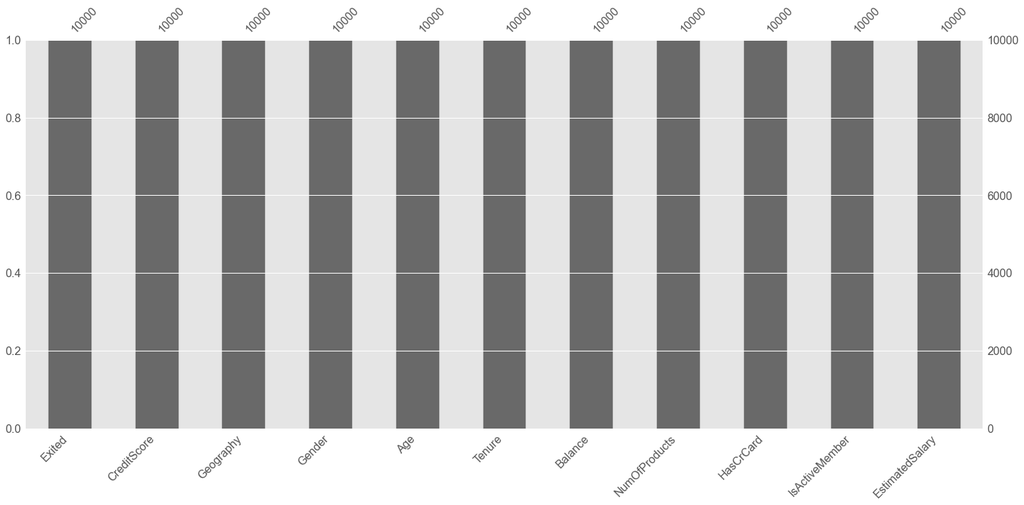

```python
msno_plot.bar(df);
```

### Unique Values

```python
df.nunique()
```

```
Exited                2
CreditScore         460
Geography             3
Gender                2
Age                  70
Tenure               11
Balance            6382
NumOfProducts         4
HasCrCard             2
IsActiveMember        2
EstimatedSalary    9999
dtype: int64
```

```python
uniqueValues = df.columns.unique()
print(uniqueValues)
```

```
Index(['Exited', 'CreditScore', 'Geography', 'Gender', 'Age', 'Tenure',
       'Balance', 'NumOfProducts', 'HasCrCard', 'IsActiveMember',
       'EstimatedSalary'],
      dtype='object')
```

### Head & Tail (first 5 / last 5 rows of data)

```python
pd.concat([df.head(5),df.tail(5)])
```

|  | Exited | CreditScore | Geography | Gender | Age | Tenure | Balance | NumOfProducts | HasCrCard | IsActiveMember | EstimatedSalary |
| --- | --- | --- | --- | --- | --- | --- | --- | --- | --- | --- | --- |
| 0 | 1 | 619 | France | Female | 42 | 2 | 0.0000 | 1 | 1 | 1 | 101,348.8800 |
| 1 | 0 | 608 | Spain | Female | 41 | 1 | 83,807.8600 | 1 | 0 | 1 | 112,542.5800 |
| 2 | 1 | 502 | France | Female | 42 | 8 | 159,660.8000 | 3 | 1 | 0 | 113,931.5700 |
| 3 | 0 | 699 | France | Female | 39 | 1 | 0.0000 | 2 | 0 | 0 | 93,826.6300 |
| 4 | 0 | 850 | Spain | Female | 43 | 2 | 125,510.8200 | 1 | 1 | 1 | 79,084.1000 |
| 9995 | 0 | 771 | France | Male | 39 | 5 | 0.0000 | 2 | 1 | 0 | 96,270.6400 |
| 9996 | 0 | 516 | France | Male | 35 | 10 | 57,369.6100 | 1 | 1 | 1 | 101,699.7700 |
| 9997 | 1 | 709 | France | Female | 36 | 7 | 0.0000 | 1 | 0 | 1 | 42,085.5800 |
| 9998 | 1 | 772 | Germany | Male | 42 | 3 | 75,075.3100 | 2 | 1 | 0 | 92,888.5200 |
| 9999 | 0 | 792 | France | Female | 28 | 4 | 130,142.7900 | 1 | 1 | 0 | 38,190.7800 |

### Separate Numeric from Categorical Attributes and One-Hot Encode Categorical Variables

```python
num_cols=[]
cat_cols=[]

for i in df.columns:
    if df[i].dtypes!=object:
        num_cols.append(i)
    else:
        cat_cols.append(i)

if len(df.columns) == len(num_cols):
    print("all columns are numeric")
else:
    print("number of numeric columns: ",len(num_cols))
    print("the numeric columns are: ", num_cols)
    print("number of categorical columns: ",len(cat_cols))
    print("the categorical columns are: ", cat_cols)
```

```
number of numeric columns:  9
the numeric columns are:  ['Exited', 'CreditScore', 'Age', 'Tenure', 'Balance', 'NumOfProducts', 'HasCrCard', 'IsActiveMember', 'EstimatedSalary']
number of categorical columns:  2
the categorical columns are:  ['Geography', 'Gender']
```

```python
df=pd.get_dummies(df,columns=['Geography','Gender'],drop_first=False, dummy_na=False)
```

```python
pd.concat([df.head(5),df.tail(5)])
```

|  | Exited | CreditScore | Age | Tenure | Balance | NumOfProducts | HasCrCard | IsActiveMember | EstimatedSalary | Geography_France | Geography_Germany | Geography_Spain | Gender_Female | Gender_Male |
| --- | --- | --- | --- | --- | --- | --- | --- | --- | --- | --- | --- | --- | --- | --- |
| 0 | 1 | 619 | 42 | 2 | 0.0000 | 1 | 1 | 1 | 101,348.8800 | 1 | 0 | 0 | 1 | 0 |
| 1 | 0 | 608 | 41 | 1 | 83,807.8600 | 1 | 0 | 1 | 112,542.5800 | 0 | 0 | 1 | 1 | 0 |
| 2 | 1 | 502 | 42 | 8 | 159,660.8000 | 3 | 1 | 0 | 113,931.5700 | 1 | 0 | 0 | 1 | 0 |
| 3 | 0 | 699 | 39 | 1 | 0.0000 | 2 | 0 | 0 | 93,826.6300 | 1 | 0 | 0 | 1 | 0 |
| 4 | 0 | 850 | 43 | 2 | 125,510.8200 | 1 | 1 | 1 | 79,084.1000 | 0 | 0 | 1 | 1 | 0 |
| 9995 | 0 | 771 | 39 | 5 | 0.0000 | 2 | 1 | 0 | 96,270.6400 | 1 | 0 | 0 | 0 | 1 |
| 9996 | 0 | 516 | 35 | 10 | 57,369.6100 | 1 | 1 | 1 | 101,699.7700 | 1 | 0 | 0 | 0 | 1 |
| 9997 | 1 | 709 | 36 | 7 | 0.0000 | 1 | 0 | 1 | 42,085.5800 | 1 | 0 | 0 | 1 | 0 |
| 9998 | 1 | 772 | 42 | 3 | 75,075.3100 | 2 | 1 | 0 | 92,888.5200 | 0 | 1 | 0 | 0 | 1 |
| 9999 | 0 | 792 | 28 | 4 | 130,142.7900 | 1 | 1 | 0 | 38,190.7800 | 1 | 0 | 0 | 1 | 0 |

## 4.2 Univariate & Multivariate Analysis

### Univariate Analysis

**Tasks Executed in this section**

1. Descriptive Statistics
2. Histograms
3. Boxplots

#### Descriptive Statistics

```python
df.describe().transpose()
```

|  | count | mean | std | min | 25% | 50% | 75% | max |
| --- | --- | --- | --- | --- | --- | --- | --- | --- |
| Exited | 10,000.0000 | 0.2037 | 0.4028 | 0.0000 | 0.0000 | 0.0000 | 0.0000 | 1.0000 |
| CreditScore | 10,000.0000 | 650.5288 | 96.6533 | 350.0000 | 584.0000 | 652.0000 | 718.0000 | 850.0000 |
| Age | 10,000.0000 | 38.9218 | 10.4878 | 18.0000 | 32.0000 | 37.0000 | 44.0000 | 92.0000 |
| Tenure | 10,000.0000 | 5.0128 | 2.8922 | 0.0000 | 3.0000 | 5.0000 | 7.0000 | 10.0000 |
| Balance | 10,000.0000 | 76,485.8893 | 62,397.4052 | 0.0000 | 0.0000 | 97,198.5400 | 127,644.2400 | 250,898.0900 |
| NumOfProducts | 10,000.0000 | 1.5302 | 0.5817 | 1.0000 | 1.0000 | 1.0000 | 2.0000 | 4.0000 |
| HasCrCard | 10,000.0000 | 0.7055 | 0.4558 | 0.0000 | 0.0000 | 1.0000 | 1.0000 | 1.0000 |
| IsActiveMember | 10,000.0000 | 0.5151 | 0.4998 | 0.0000 | 0.0000 | 1.0000 | 1.0000 | 1.0000 |
| EstimatedSalary | 10,000.0000 | 100,090.2399 | 57,510.4928 | 11.5800 | 51,002.1100 | 100,193.9150 | 149,388.2475 | 199,992.4800 |
| Geography_France | 10,000.0000 | 0.5014 | 0.5000 | 0.0000 | 0.0000 | 1.0000 | 1.0000 | 1.0000 |
| Geography_Germany | 10,000.0000 | 0.2509 | 0.4336 | 0.0000 | 0.0000 | 0.0000 | 1.0000 | 1.0000 |
| Geography_Spain | 10,000.0000 | 0.2477 | 0.4317 | 0.0000 | 0.0000 | 0.0000 | 0.0000 | 1.0000 |
| Gender_Female | 10,000.0000 | 0.4543 | 0.4979 | 0.0000 | 0.0000 | 0.0000 | 1.0000 | 1.0000 |
| Gender_Male | 10,000.0000 | 0.5457 | 0.4979 | 0.0000 | 0.0000 | 1.0000 | 1.0000 | 1.0000 |

#### Histograms

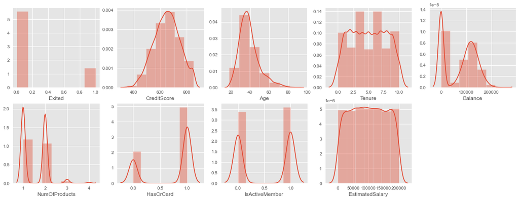

```python
# distributions of numerical (continuous) attributes
col_num = df[num_cols]
bins=7
plt.figure(figsize= (20,15))  # setting the figure size
pos = 1  # we will use this variable to index each of the plots
j=1
for i in col_num:
    plt.subplot(4, 5, pos)
    sns.distplot(df[i], bins=bins)
    pos += 1
```

```python
for i in col_num:
    value = df[i].value_counts(normalize=True).sort_index().round(2)
    print("for ", i)
    print(value)
    print()
```

```
for  Exited
0   0.8000
1   0.2000
Name: Exited, dtype: float64

for  CreditScore
350   0.0000
351   0.0000
358   0.0000
359   0.0000
363   0.0000
       ...
846   0.0000
847   0.0000
848   0.0000
849   0.0000
850   0.0200
Name: CreditScore, Length: 460, dtype: float64

for  Age
18   0.0000
19   0.0000
20   0.0000
21   0.0100
22   0.0100
      ...
83   0.0000
84   0.0000
85   0.0000
88   0.0000
92   0.0000
Name: Age, Length: 70, dtype: float64

for  Tenure
0    0.0400
1    0.1000
2    0.1000
3    0.1000
4    0.1000
5    0.1000
```

[output cut: 36 more lines]

```
Name: IsActiveMember, dtype: float64

for  EstimatedSalary
11.5800        0.0000
90.0700        0.0000
91.7500        0.0000
96.2700        0.0000
106.6700       0.0000
                ...
199,909.3200   0.0000
199,929.1700   0.0000
199,953.3300   0.0000
199,970.7400   0.0000
199,992.4800   0.0000
Name: EstimatedSalary, Length: 9999, dtype: float64
```

#### Boxplots

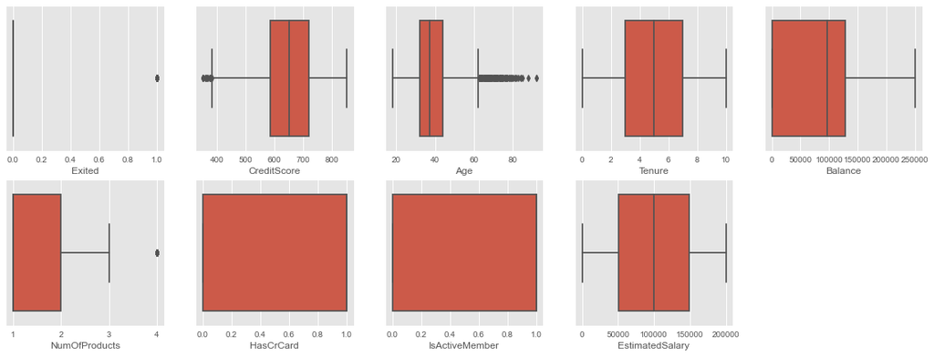

```python
col_num = df[num_cols]
plt.figure(figsize=(20,15))
pos = 1
for i in col_num:
    plt.subplot(4, 5, pos)
    sns.boxplot(df[i])
    pos += 1
```

### Multivariate Analysis

1. RadViz is a multivariate data visualization algorithm that plots each feature dimension uniformly around the circumference of a circle.
2. It then plots points on the interior of the circle such that the point normalizes its values on the axes from the center to each arc.
3. This mechanism allows as many dimensions as will easily fit on a circle, greatly expanding the dimensionality of the visualization.
4. Data scientists use this method to detect separability between classes. E.g. is there an opportunity to learn from the feature set or is there just too much noise?
5. RadViz allow to project a N-dimensional data set into a 2D space where the influence of each dimension can be interpreted as a balance between the influence of all dimensions.
6. Each Series in the DataFrame is represented as a evenly distributed slice on a circle.
7. Each data point is rendered in the circle according to the value on each Series.
8. Highly correlated Series in the DataFrame are placed closer on the unit circle.

From: https://www.scikit-yb.org/en/latest/api/features/radviz , https://pandas.pydata.org/docs/reference/api/pandas.plotting.radviz

```python
from pandas.plotting import radviz
opts2 = df.columns.values
dfrv=df.iloc[:, :-1]
selector2 = widgets.RadioButtons(options=opts2, description='Select Target:', disabled=False)

output2 = widgets.Output()
display(selector2)
display(output2)

def radplot(widg):
    choices = widg['new']
    data = df.loc[:, choices] if choices else df
    output2.clear_output(wait=True)
    with output2:
        fig, ax = plt.subplots(figsize=(13, 6))
        dfrv['target_bins']= pd.cut(df[selector2.value], 11)
        ax = radviz(dfrv, "target_bins", colormap="bwr")
        plt.show()

selector2.observe(radplot,names = 'value')
```

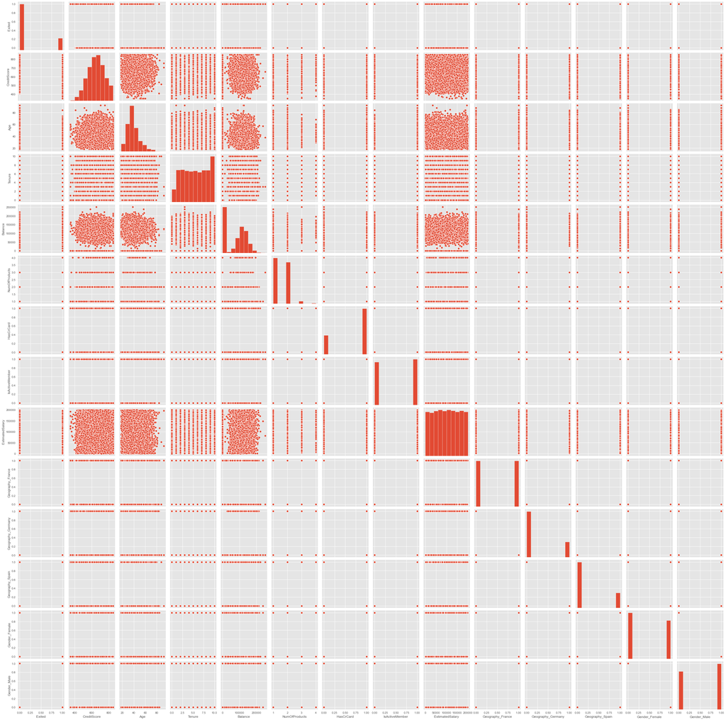

```python
sns.pairplot(df)
```

```python
opts4 = df.columns.values
selector4 = widgets.RadioButtons(options=opts4, description='Select Hue Attribute:', disabled=False)

output4 = widgets.Output()
display(selector4)
display(output4)

def pairplot3(widg):
    choices = widg['new']
    data = df.loc[:, choices] if choices else df
    output4.clear_output(wait=True)
    with output4:
        df['hue_bins']= pd.cut(df[selector4.value], 2)
        ax = sns.pairplot(df, hue = "hue_bins",  palette="husl")
        plt.show()
selector4.observe(pairplot3,names = 'value')
```

#### Correlations / Collinearity

```python
df.corr() # It will show correlation of only numerical variables here.
```

|  | Exited | CreditScore | Age | Tenure | Balance | NumOfProducts | HasCrCard | IsActiveMember | EstimatedSalary | Geography_France | Geography_Germany | Geography_Spain | Gender_Female | Gender_Male |
| --- | --- | --- | --- | --- | --- | --- | --- | --- | --- | --- | --- | --- | --- | --- |
| Exited | 1.0000 | -0.0271 | 0.2853 | -0.0140 | 0.1185 | -0.0478 | -0.0071 | -0.1561 | 0.0121 | -0.1050 | 0.1735 | -0.0527 | 0.1065 | -0.1065 |
| CreditScore | -0.0271 | 1.0000 | -0.0040 | 0.0008 | 0.0063 | 0.0122 | -0.0055 | 0.0257 | -0.0014 | -0.0089 | 0.0055 | 0.0048 | 0.0029 | -0.0029 |
| Age | 0.2853 | -0.0040 | 1.0000 | -0.0100 | 0.0283 | -0.0307 | -0.0117 | 0.0855 | -0.0072 | -0.0392 | 0.0469 | -0.0017 | 0.0275 | -0.0275 |
| Tenure | -0.0140 | 0.0008 | -0.0100 | 1.0000 | -0.0123 | 0.0134 | 0.0226 | -0.0284 | 0.0078 | -0.0028 | -0.0006 | 0.0039 | -0.0147 | 0.0147 |
| Balance | 0.1185 | 0.0063 | 0.0283 | -0.0123 | 1.0000 | -0.3042 | -0.0149 | -0.0101 | 0.0128 | -0.2313 | 0.4011 | -0.1349 | -0.0121 | 0.0121 |
| NumOfProducts | -0.0478 | 0.0122 | -0.0307 | 0.0134 | -0.3042 | 1.0000 | 0.0032 | 0.0096 | 0.0142 | 0.0012 | -0.0104 | 0.0090 | 0.0219 | -0.0219 |
| HasCrCard | -0.0071 | -0.0055 | -0.0117 | 0.0226 | -0.0149 | 0.0032 | 1.0000 | -0.0119 | -0.0099 | 0.0025 | 0.0106 | -0.0135 | -0.0058 | 0.0058 |
| IsActiveMember | -0.1561 | 0.0257 | 0.0855 | -0.0284 | -0.0101 | 0.0096 | -0.0119 | 1.0000 | -0.0114 | 0.0033 | -0.0205 | 0.0167 | -0.0225 | 0.0225 |
| EstimatedSalary | 0.0121 | -0.0014 | -0.0072 | 0.0078 | 0.0128 | 0.0142 | -0.0099 | -0.0114 | 1.0000 | -0.0033 | 0.0103 | -0.0065 | 0.0081 | -0.0081 |
| Geography_France | -0.1050 | -0.0089 | -0.0392 | -0.0028 | -0.2313 | 0.0012 | 0.0025 | 0.0033 | -0.0033 | 1.0000 | -0.5804 | -0.5754 | -0.0068 | 0.0068 |
| Geography_Germany | 0.1735 | 0.0055 | 0.0469 | -0.0006 | 0.4011 | -0.0104 | 0.0106 | -0.0205 | 0.0103 | -0.5804 | 1.0000 | -0.3321 | 0.0246 | -0.0246 |
| Geography_Spain | -0.0527 | 0.0048 | -0.0017 | 0.0039 | -0.1349 | 0.0090 | -0.0135 | 0.0167 | -0.0065 | -0.5754 | -0.3321 | 1.0000 | -0.0169 | 0.0169 |
| Gender_Female | 0.1065 | 0.0029 | 0.0275 | -0.0147 | -0.0121 | 0.0219 | -0.0058 | -0.0225 | 0.0081 | -0.0068 | 0.0246 | -0.0169 | 1.0000 | -1.0000 |
| Gender_Male | -0.1065 | -0.0029 | -0.0275 | 0.0147 | 0.0121 | -0.0219 | 0.0058 | 0.0225 | -0.0081 | 0.0068 | -0.0246 | 0.0169 | -1.0000 | 1.0000 |

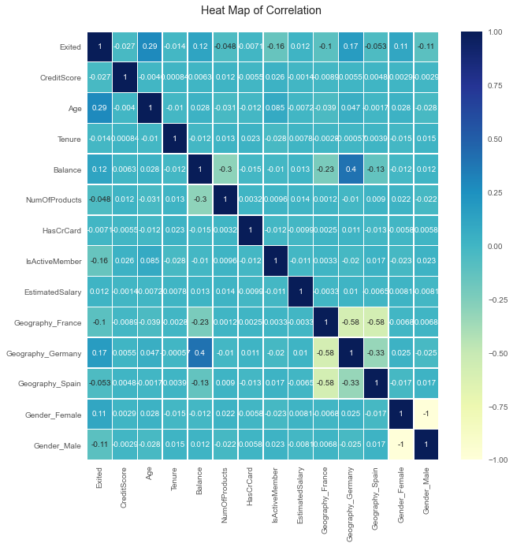

```python
corr = df.corr();
fig, ax = plt.subplots()
fig.set_size_inches(10, 10)
plt.title('Heat Map of Correlation \n')
sns.heatmap(corr,annot=True,cmap='YlGnBu',vmin=-1,vmax=1, linewidths=.5, center=0);
```

**On Correlation Heatmap (chart below)**

1. Display the feature spearman's correlation matrix as a heatmap with any abs(value)>color_threshold appearing with background color.
2. Spearman's correlation is the same thing as converting two variables to rank values and then running a standard Pearson's correlation on those ranked variables.
3. Spearman's is nonparametric and does not assume a linear relationship between the variables; it looks for monotonic relationships.
4. Because it is a symmetric matrix, only the upper triangle is shown. The diagonal is all x's since auto-correlation is not useful.

From: https://github.com/parrt/random-forest-importances/blob/master/src/rfpimp.py, https://explained.ai/rf-importance/

```python
df.shape
```

```
(10000, 14)
```

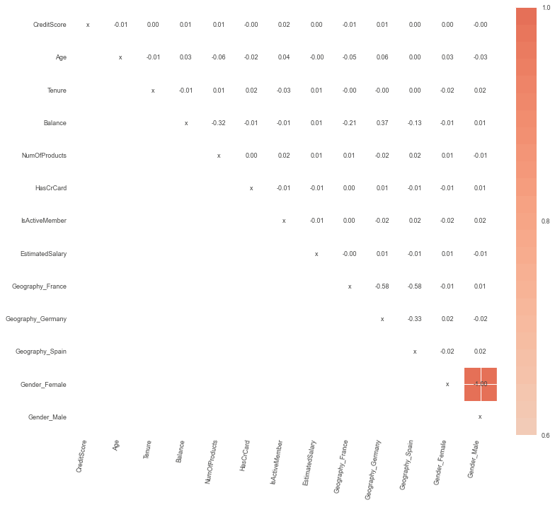

```python
predictors = df.iloc[:, 1:14]
from rfpimp import plot_corr_heatmap
viz = plot_corr_heatmap(predictors, figsize=(11,11), label_fontsize=9, value_fontsize=9)
```

**On Shapiro-Wilks, Covarience, and Pearson's Ranking Algorithms used in charts below**

1. A one-dimensional ranking of features utilizes a ranking algorithm that takes into account only a single feature at a time (e.g. histogram analysis).
2. Shapiro-Wilk algorithm to assess the normality of the distribution of instances with respect to the feature.
3. A barplot is then drawn showing the relative ranks of each feature.
4. A two-dimensional ranking of features utilizes a ranking algorithm that takes into account pairs of features at a time (e.g. joint plot analysis).
5. The pairs of features are then ranked by score and visualized using the lower left triangle of a feature co-occurence matrix
6. The covariance ranking algorithm, attempts to compute the mean value of the product of deviations of variates from their respective means.
7. Covariance loosely attempts to detect a colinear relationship between features.

From: https://www.scikit-yb.org/en/latest/api/features/rankd

```python
df.columns
```

```
Index(['Exited', 'CreditScore', 'Age', 'Tenure', 'Balance', 'NumOfProducts',
       'HasCrCard', 'IsActiveMember', 'EstimatedSalary', 'Geography_France',
       'Geography_Germany', 'Geography_Spain', 'Gender_Female', 'Gender_Male'],
      dtype='object')
```

```python
df.info()
```

```
<class 'pandas.core.frame.DataFrame'>
Int64Index: 10000 entries, 0 to 9999
Data columns (total 14 columns):
 #   Column             Non-Null Count  Dtype
---  ------             --------------  -----
 0   Exited             10000 non-null  int64
 1   CreditScore        10000 non-null  int64
 2   Age                10000 non-null  int64
 3   Tenure             10000 non-null  int64
 4   Balance            10000 non-null  float64
 5   NumOfProducts      10000 non-null  int64
 6   HasCrCard          10000 non-null  int64
 7   IsActiveMember     10000 non-null  int64
 8   EstimatedSalary    10000 non-null  float64
 9   Geography_France   10000 non-null  uint8
 10  Geography_Germany  10000 non-null  uint8
 11  Geography_Spain    10000 non-null  uint8
 12  Gender_Female      10000 non-null  uint8
 13  Gender_Male        10000 non-null  uint8
dtypes: float64(2), int64(7), uint8(5)
memory usage: 1.1 MB
```

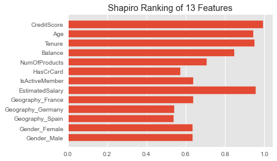

```python
from yellowbrick.features import Rank1D
from yellowbrick.features import Rank2D

feature_names = ['CreditScore', 'Age', 'Tenure', 'Balance', 'NumOfProducts',
       'HasCrCard', 'IsActiveMember', 'EstimatedSalary', 'Geography_France',
       'Geography_Germany', 'Geography_Spain', 'Gender_Female', 'Gender_Male']
target_name = 'Exited'
X = df[feature_names]
y = df[target_name]

# Instantiate the 1D visualizer with the Sharpiro ranking algorithm
visualizer = Rank1D(features=feature_names, algorithm='shapiro')
visualizer.fit(X, y)                # fit the data to the visualizer
visualizer.transform(X)             # transform the data
visualizer.poof()                   # visualise
```

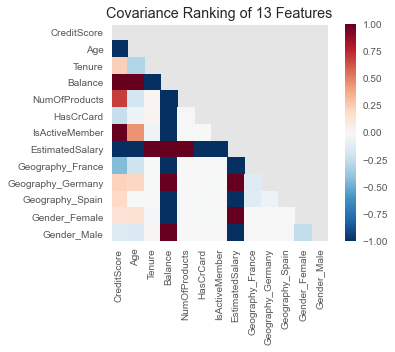

```python
# Instantiate the visualizer with the Covariance ranking algorithm
visualizer = Rank2D(features=feature_names, algorithm='covariance')
visualizer.fit(X, y)
visualizer.transform(X)
visualizer.poof()
```

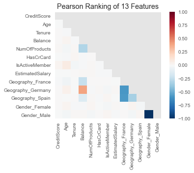

```python
# Instantiate the visualizer with the Pearson ranking algorithm
visualizer = Rank2D(features=feature_names, algorithm='pearson')
visualizer.fit(X, y)
visualizer.transform(X)
visualizer.poof()
```

# 5. Prepare the Data

Back to Table of Contents

```python
df.describe().transpose()
```

|  | count | mean | std | min | 25% | 50% | 75% | max |
| --- | --- | --- | --- | --- | --- | --- | --- | --- |
| Exited | 10,000.0000 | 0.2037 | 0.4028 | 0.0000 | 0.0000 | 0.0000 | 0.0000 | 1.0000 |
| CreditScore | 10,000.0000 | 650.5288 | 96.6533 | 350.0000 | 584.0000 | 652.0000 | 718.0000 | 850.0000 |
| Age | 10,000.0000 | 38.9218 | 10.4878 | 18.0000 | 32.0000 | 37.0000 | 44.0000 | 92.0000 |
| Tenure | 10,000.0000 | 5.0128 | 2.8922 | 0.0000 | 3.0000 | 5.0000 | 7.0000 | 10.0000 |
| Balance | 10,000.0000 | 76,485.8893 | 62,397.4052 | 0.0000 | 0.0000 | 97,198.5400 | 127,644.2400 | 250,898.0900 |
| NumOfProducts | 10,000.0000 | 1.5302 | 0.5817 | 1.0000 | 1.0000 | 1.0000 | 2.0000 | 4.0000 |
| HasCrCard | 10,000.0000 | 0.7055 | 0.4558 | 0.0000 | 0.0000 | 1.0000 | 1.0000 | 1.0000 |
| IsActiveMember | 10,000.0000 | 0.5151 | 0.4998 | 0.0000 | 0.0000 | 1.0000 | 1.0000 | 1.0000 |
| EstimatedSalary | 10,000.0000 | 100,090.2399 | 57,510.4928 | 11.5800 | 51,002.1100 | 100,193.9150 | 149,388.2475 | 199,992.4800 |
| Geography_France | 10,000.0000 | 0.5014 | 0.5000 | 0.0000 | 0.0000 | 1.0000 | 1.0000 | 1.0000 |
| Geography_Germany | 10,000.0000 | 0.2509 | 0.4336 | 0.0000 | 0.0000 | 0.0000 | 1.0000 | 1.0000 |
| Geography_Spain | 10,000.0000 | 0.2477 | 0.4317 | 0.0000 | 0.0000 | 0.0000 | 0.0000 | 1.0000 |
| Gender_Female | 10,000.0000 | 0.4543 | 0.4979 | 0.0000 | 0.0000 | 0.0000 | 1.0000 | 1.0000 |
| Gender_Male | 10,000.0000 | 0.5457 | 0.4979 | 0.0000 | 0.0000 | 1.0000 | 1.0000 | 1.0000 |

```python
df.columns
```

```
Index(['Exited', 'CreditScore', 'Age', 'Tenure', 'Balance', 'NumOfProducts',
       'HasCrCard', 'IsActiveMember', 'EstimatedSalary', 'Geography_France',
       'Geography_Germany', 'Geography_Spain', 'Gender_Female', 'Gender_Male'],
      dtype='object')
```

```python
df=df.drop(['Geography_Spain', 'Gender_Female'],axis=1)
```

```python
df.info()
```

```
<class 'pandas.core.frame.DataFrame'>
Int64Index: 10000 entries, 0 to 9999
Data columns (total 12 columns):
 #   Column             Non-Null Count  Dtype
---  ------             --------------  -----
 0   Exited             10000 non-null  int64
 1   CreditScore        10000 non-null  int64
 2   Age                10000 non-null  int64
 3   Tenure             10000 non-null  int64
 4   Balance            10000 non-null  float64
 5   NumOfProducts      10000 non-null  int64
 6   HasCrCard          10000 non-null  int64
 7   IsActiveMember     10000 non-null  int64
 8   EstimatedSalary    10000 non-null  float64
 9   Geography_France   10000 non-null  uint8
 10  Geography_Germany  10000 non-null  uint8
 11  Gender_Male        10000 non-null  uint8
dtypes: float64(2), int64(7), uint8(3)
memory usage: 1.1 MB
```

```python
df.columns
```

```
Index(['Exited', 'CreditScore', 'Age', 'Tenure', 'Balance', 'NumOfProducts',
       'HasCrCard', 'IsActiveMember', 'EstimatedSalary', 'Geography_France',
       'Geography_Germany', 'Gender_Male'],
      dtype='object')
```

```python
# Import `train_test_split` from `sklearn.model_selection`
from sklearn.model_selection import train_test_split

# Specify the data
X=df.iloc[:,1:11]

# Specify the target labels and flatten array
y= df.Exited


# Split the data up in train and test sets
X_train, X_test, y_train, y_test = train_test_split(X, y, test_size=0.30, random_state=42)

y_train =  np.array(y_train)
y_test =  np.array(y_test)
```

```python
# Define the scaler
scaler = StandardScaler().fit(X_train)

# Scale the train set
X_train = scaler.transform(X_train)

# Scale the test set
X_test = scaler.transform(X_test)
```